# MLProject-3

N° student : 28619793

Nom : MINLOUBOU

Prénoms : David Dethan Kevin

**PROJECT**

To be done in group of 3 or 4 students. But I did it myself.

**Shoppers's intention online**

The dataset contains the following features:

- Administrative: This is the number of pages of this type (administrative) that the user visited.
- Administrative_Duration: This is the amount of time spent in this category of pages.
- Informational: This is the number of pages of this type (informational) that the user visited.
- Informational_Duration: This is the amount of time spent in this category of pages.
- ProductRelated: This is the number of pages of this type (product related) that the user visited.
- ProductRelated_Duration: This is the amount of time spent in this category of pages.
- BounceRates: The percentage of visitors who enter the website through that page and exit without triggering any additional tasks.
- ExitRates: The percentage of pageviews on the website that end at that specific page.
- PageValues: The average value of the page averaged over the value of the target page and/or the completion of an eCommerce transaction. [More information about how this is calculated](https://support.google.com/analytics/answer/2695658?hl=en)
- SpecialDay: This value represents the closeness of the browsing date to special days or holidays (eg Mother's Day or Valentine's day) in which the transaction is more likely to be finalized.
- Month: Contains the month the pageview occurred, in string form.
- OperatingSystems: An integer value representing the operating system that the user was on when viewing the page.
- Browser: An integer value representing the browser that the user was using to view the page.
- Region: An integer value representing which region the user is located in.
- TrafficType: An integer value representing what type of traffic the user is categorized into. [Read more about traffic types here.](https://www.practicalecommerce.com/Understanding-Traffic-Sources-in-Google-Analytics)
- VisitorType: A string representing whether a visitor is New Visitor, Returning Visitor, or Other.
- Weekend: A boolean representing whether the session is on a weekend.
- Revenue: A boolean representing whether or not the user completed the purchase.

**Your job**

- Understand the data, visualize it.
- Use different machine learning's methods to predict shoppers' intention.

**Our purpose**

- Prediction results and mean squared error obtained on the test set for the methods you considered.
- A discussion about the impact of the hyperparameters of the methods on your predictions.
- A clear comparison between your solutions (a table, and/or plots comparing the results obtained with different methods)
- Élément de liste

**Deadline**

- via Moodle for all Sorbonne University students

**Machine learning's methods**

Unsupervised learning methods and visualization :

- PCA
- kmeans
- Mixture model

Supervised learning methods :

- Logistc Regression
- K Nearest Neighbors
- Support Vector Machine
- Random Forest Classifier
- Adaboost Clasifier
- Gradient Boosting Classifier
- Extra Trees
- Neural Network

```python
from google.colab import drive
drive.mount('/content/drive')
```

**Data Preparation**

I found the dataset on Kaggle, and i decided to put in on my github, to facilitate the data recuperation.

```python
%tensorflow_version 2.x
import tensorflow as tf
device_name = tf.test.gpu_device_name()
if device_name != '/device:GPU:0':
  raise SystemError('GPU device not found')
print('Found GPU at: {}'.format(device_name))
```

```
Found GPU at: /device:GPU:0
```

```python
import pandas as pd
import numpy as np
import seaborn as sns
import matplotlib.pyplot as plt
import matplotlib as mpl
from sklearn.preprocessing import OneHotEncoder
import matplotlib.pylab as pylab
from scipy import stats
from sklearn.compose import make_column_transformer
from sklearn.preprocessing import StandardScaler,MinMaxScaler,OrdinalEncoder,LabelEncoder
from sklearn.preprocessing import PowerTransformer
from sklearn.model_selection import train_test_split,GridSearchCV,RandomizedSearchCV
from sklearn.svm import SVC
from sklearn import metrics
from sklearn.linear_model import LogisticRegression
from sklearn.discriminant_analysis import LinearDiscriminantAnalysis,QuadraticDiscriminantAnalysis
from sklearn.metrics import accuracy_score
from sklearn.cluster import KMeans
import tensorflow as tf
from sklearn.neighbors import KNeighborsClassifier
from sklearn.cluster import KMeans
from sklearn.decomposition import PCA


from sklearn.linear_model import LogisticRegression
from sklearn.model_selection import cross_val_score,RandomizedSearchCV
from sklearn import metrics
from sklearn import model_selection
from sklearn.tree import DecisionTreeClassifier
from sklearn.linear_model import LogisticRegression
from sklearn.naive_bayes import GaussianNB
from sklearn.neighbors import KNeighborsClassifier
from sklearn.tree import DecisionTreeClassifier
from sklearn.ensemble import RandomForestClassifier,BaggingClassifier,AdaBoostClassifier,GradientBoostingClassifier,ExtraTreesClassifier
from xgboost import XGBClassifier
from sklearn.mixture import BayesianGaussianMixture
from scipy.stats import randint as sp_randint

from keras.models import Sequential
from keras.layers import Dense, Dropout, Flatten
from keras import activations, layers
from keras.callbacks import EarlyStopping

from sklearn.metrics import classification_report
from prettytable import PrettyTable

%matplotlib inline
sns.set_theme()

mpl.style.use('ggplot')
sns.set_style('white')
pylab.rcParams['figure.figsize'] = 12,8
```

```python
url ='https://raw.githubusercontent.com/MinloubouDavid/ML/main/online_shoppers_intention.csv'
shop = pd.read_csv(url)
```

```python
shop
```

|  | Administrative | Administrative_Duration | Informational | Informational_Duration | ProductRelated | ProductRelated_Duration | BounceRates | ExitRates | PageValues | SpecialDay | Month | OperatingSystems | Browser | Region | TrafficType | VisitorType | Weekend | Revenue |
| --- | --- | --- | --- | --- | --- | --- | --- | --- | --- | --- | --- | --- | --- | --- | --- | --- | --- | --- |
| 0 | 0 | 0.0 | 0 | 0.0 | 1 | 0.000000 | 0.200000 | 0.200000 | 0.000000 | 0.0 | Feb | 1 | 1 | 1 | 1 | Returning_Visitor | False | False |
| 1 | 0 | 0.0 | 0 | 0.0 | 2 | 64.000000 | 0.000000 | 0.100000 | 0.000000 | 0.0 | Feb | 2 | 2 | 1 | 2 | Returning_Visitor | False | False |
| 2 | 0 | 0.0 | 0 | 0.0 | 1 | 0.000000 | 0.200000 | 0.200000 | 0.000000 | 0.0 | Feb | 4 | 1 | 9 | 3 | Returning_Visitor | False | False |
| 3 | 0 | 0.0 | 0 | 0.0 | 2 | 2.666667 | 0.050000 | 0.140000 | 0.000000 | 0.0 | Feb | 3 | 2 | 2 | 4 | Returning_Visitor | False | False |
| 4 | 0 | 0.0 | 0 | 0.0 | 10 | 627.500000 | 0.020000 | 0.050000 | 0.000000 | 0.0 | Feb | 3 | 3 | 1 | 4 | Returning_Visitor | True | False |
| ... | ... | ... | ... | ... | ... | ... | ... | ... | ... | ... | ... | ... | ... | ... | ... | ... | ... | ... |
| 12325 | 3 | 145.0 | 0 | 0.0 | 53 | 1783.791667 | 0.007143 | 0.029031 | 12.241717 | 0.0 | Dec | 4 | 6 | 1 | 1 | Returning_Visitor | True | False |
| 12326 | 0 | 0.0 | 0 | 0.0 | 5 | 465.750000 | 0.000000 | 0.021333 | 0.000000 | 0.0 | Nov | 3 | 2 | 1 | 8 | Returning_Visitor | True | False |
| 12327 | 0 | 0.0 | 0 | 0.0 | 6 | 184.250000 | 0.083333 | 0.086667 | 0.000000 | 0.0 | Nov | 3 | 2 | 1 | 13 | Returning_Visitor | True | False |
| 12328 | 4 | 75.0 | 0 | 0.0 | 15 | 346.000000 | 0.000000 | 0.021053 | 0.000000 | 0.0 | Nov | 2 | 2 | 3 | 11 | Returning_Visitor | False | False |
| 12329 | 0 | 0.0 | 0 | 0.0 | 3 | 21.250000 | 0.000000 | 0.066667 | 0.000000 | 0.0 | Nov | 3 | 2 | 1 | 2 | New_Visitor | True | False |

12330 rows × 18 columns

The dataset is properly telecarmed. We can try before to study the variables, see what types of data we have, and see whether or not we have missing data or consecutive data.

```python
str(shop.info())
```

```
<class 'pandas.core.frame.DataFrame'>
RangeIndex: 12330 entries, 0 to 12329
Data columns (total 18 columns):
 #   Column                   Non-Null Count  Dtype
---  ------                   --------------  -----
 0   Administrative           12330 non-null  int64
 1   Administrative_Duration  12330 non-null  float64
 2   Informational            12330 non-null  int64
 3   Informational_Duration   12330 non-null  float64
 4   ProductRelated           12330 non-null  int64
 5   ProductRelated_Duration  12330 non-null  float64
 6   BounceRates              12330 non-null  float64
 7   ExitRates                12330 non-null  float64
 8   PageValues               12330 non-null  float64
 9   SpecialDay               12330 non-null  float64
 10  Month                    12330 non-null  object
 11  OperatingSystems         12330 non-null  int64
 12  Browser                  12330 non-null  int64
 13  Region                   12330 non-null  int64
 14  TrafficType              12330 non-null  int64
 15  VisitorType              12330 non-null  object
 16  Weekend                  12330 non-null  bool
 17  Revenue                  12330 non-null  bool
dtypes: bool(2), float64(7), int64(7), object(2)
memory usage: 1.5+ MB
```

```
'None'
```

It will be necessary to change the type of variables VisitorType ,Browser,TrafficType,OperatingSystems because they are supposed to represent categories (groups).

```python
shop.OperatingSystems = shop.OperatingSystems.astype(str)
shop.Browser = shop.Browser.astype(str)
shop.Region = shop.Region.astype(str)
shop.TrafficType = shop.TrafficType.astype(str)

print("Columns converted to string")
```

```
Columns converted to string
```

```python
(shop.isna().sum())
```

```
Administrative             0
Administrative_Duration    0
Informational              0
Informational_Duration     0
ProductRelated             0
ProductRelated_Duration    0
BounceRates                0
ExitRates                  0
PageValues                 0
SpecialDay                 0
Month                      0
OperatingSystems           0
Browser                    0
Region                     0
TrafficType                0
VisitorType                0
Weekend                    0
Revenue                    0
dtype: int64
```

We have 12330 instances in dataset. There also no missing data, the dataset seems pretty clean.

```python
(shop["Month"].value_counts())
```

```
May     3364
Nov     2998
Mar     1907
Dec     1727
Oct      549
Sep      448
Aug      433
Jul      432
June     288
Feb      184
Name: Month, dtype: int64
```

```python
shop["VisitorType"].value_counts()
```

```
Returning_Visitor    10551
New_Visitor           1694
Other                   85
Name: VisitorType, dtype: int64
```

We can see here that they don't have many categories.

Let's have a global view to our numerical features with a quick summary.

```python
shop.describe()
```

|  | Administrative | Administrative_Duration | Informational | Informational_Duration | ProductRelated | ProductRelated_Duration | BounceRates | ExitRates | PageValues | SpecialDay |
| --- | --- | --- | --- | --- | --- | --- | --- | --- | --- | --- |
| count | 12330.000000 | 12330.000000 | 12330.000000 | 12330.000000 | 12330.000000 | 12330.000000 | 12330.000000 | 12330.000000 | 12330.000000 | 12330.000000 |
| mean | 2.315166 | 80.818611 | 0.503569 | 34.472398 | 31.731468 | 1194.746220 | 0.022191 | 0.043073 | 5.889258 | 0.061427 |
| std | 3.321784 | 176.779107 | 1.270156 | 140.749294 | 44.475503 | 1913.669288 | 0.048488 | 0.048597 | 18.568437 | 0.198917 |
| min | 0.000000 | 0.000000 | 0.000000 | 0.000000 | 0.000000 | 0.000000 | 0.000000 | 0.000000 | 0.000000 | 0.000000 |
| 25% | 0.000000 | 0.000000 | 0.000000 | 0.000000 | 7.000000 | 184.137500 | 0.000000 | 0.014286 | 0.000000 | 0.000000 |
| 50% | 1.000000 | 7.500000 | 0.000000 | 0.000000 | 18.000000 | 598.936905 | 0.003112 | 0.025156 | 0.000000 | 0.000000 |
| 75% | 4.000000 | 93.256250 | 0.000000 | 0.000000 | 38.000000 | 1464.157213 | 0.016813 | 0.050000 | 0.000000 | 0.000000 |
| max | 27.000000 | 3398.750000 | 24.000000 | 2549.375000 | 705.000000 | 63973.522230 | 0.200000 | 0.200000 | 361.763742 | 1.000000 |

```python
shop.describe(include=['object','bool'])
```

|  | Month | OperatingSystems | Browser | Region | TrafficType | VisitorType |
| --- | --- | --- | --- | --- | --- | --- |
| count | 12330 | 12330 | 12330 | 12330 | 12330 | 12330 |
| unique | 10 | 8 | 13 | 9 | 20 | 3 |
| top | May | 2 | 2 | 1 | 2 | Returning_Visitor |
| freq | 3364 | 6601 | 7961 | 4780 | 3913 | 10551 |

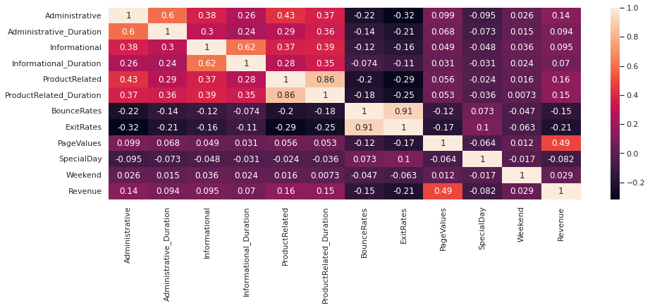

```python
plt.figure(figsize=(15,5))
sns.heatmap(shop.corr(),annot=True)
```

**Remove outliers**

The dataset don't contains missing values. Check if we have outliers , ans remove them.

```python
numerical_features = shop.select_dtypes(include=[np.number]).columns
len(numerical_features)
```

```
10
```

```python
numerical_features
```

```
Index(['Administrative', 'Administrative_Duration', 'Informational',
       'Informational_Duration', 'ProductRelated', 'ProductRelated_Duration',
       'BounceRates', 'ExitRates', 'PageValues', 'SpecialDay'],
      dtype='object')
```

```python
def boxplots(df,num_feature):
  i=0
  plt.figure(figsize=(40,20))
  for column in num_feature:
    plt.subplot(5,3,i+1)
    sns.boxplot(shop[column])
    plt.xlabel(column)
    i+=1
  plt.show()
```

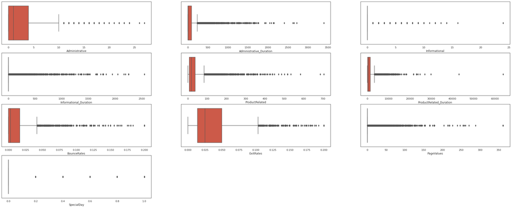

```python
boxplots(shop,numerical_features)
```

We notice that we have quite a few aberrant valuers. Let's define a function to retrieve all indexes where it is suspected that there are aberrant valuers.

```python
def find_outliers(v):
  Q1 = np.quantile(v,0.25)
  Q3 = np.quantile(v,0.75)
  EIQ = Q3-Q1
  LI = Q1-(1.5*EIQ)
  LS = Q3 + (1.5*EIQ)
  index = list(v.index[(v<LI) | (v>LS)])
  return index
```

```python
index_list=[]
for column in numerical_features:
  index= find_outliers(shop[column])
  index_list.extend(index)
```

```python
len(set(index_list))
```

```
7072
```

We see that we do not really have an interest in erasing the 7072 instances otherwise, we lose more than half of the nearly 50% of the data, let's look for another way to be able to remove the outliers.

A another method is to remove outliers by calculating z-score which is equals to (Observation — Mean)/Standard Deviation : $ z_{score} = \frac{(X-μ)}{σ}$.

We find the z score for each of the data point in the dataset and if the z score is greater than 3.5 than we can classify that point as an outlier.

```python
def remove_outliers(data, l, z):
    for var in l:
        result = data[np.abs(stats.zscore(data[var])) < z]
    return result

shop = remove_outliers(shop, numerical_features,3.5)
```

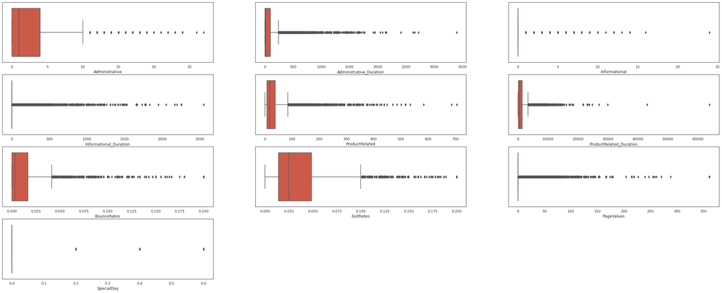

```python
boxplots(shop,numerical_features)
```

```python
index_list=[]
for column in numerical_features:
  index= find_outliers(shop[column])
  index_list.extend(index)
len(set(index_list))
```

```
6583
```

**Visualize data**

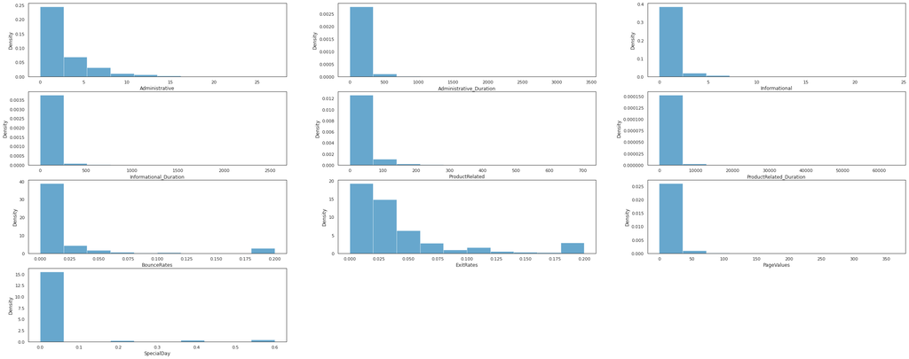

```python
plt.figure(figsize=(40,20))
i=0
for col in numerical_features:
  plt.subplot(5,3,i+1)
  sns.histplot(shop[col],bins=10,stat="density")
  i+=1
plt.show()
```

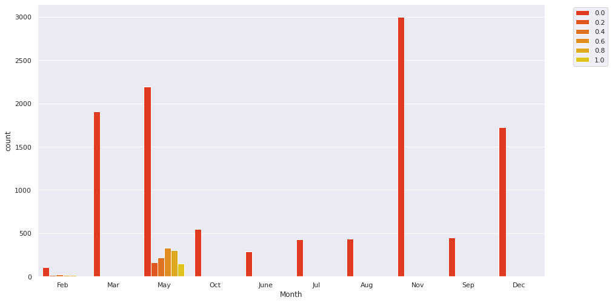

```python
sns.set(rc={'figure.figsize':(15,8.27)})
sns.set_theme(style="darkgrid")
sns.countplot(shop['Month'],hue=shop['SpecialDay'],palette='autumn')
plt.legend(bbox_to_anchor=(1.05, 1))
plt.show()
```

SpecialDay in specially in May.

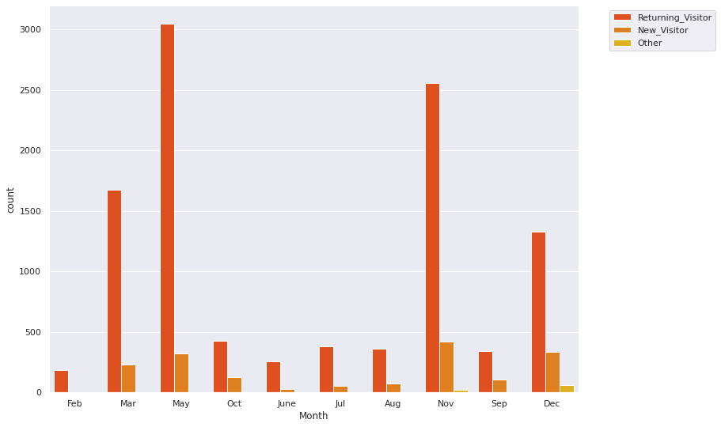

```python
sns.set(rc={'figure.figsize':(12,9)})
sns.set_theme(style="darkgrid")
sns.countplot(shop['Month'],hue=shop['VisitorType'],palette='autumn')
plt.legend(bbox_to_anchor=(1.05, 1))
plt.show()
```

[output not shown]

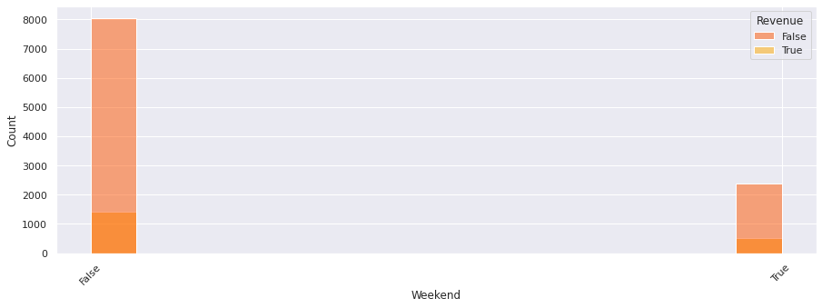

```python
plt.figure(figsize=(15,5))
sns.histplot(shop,x="Weekend",hue="Revenue",palette="autumn")
plt.xticks([0,1],["False","True"],rotation=45)
```

We have far fewer online purchases on weekends.

[output not shown]

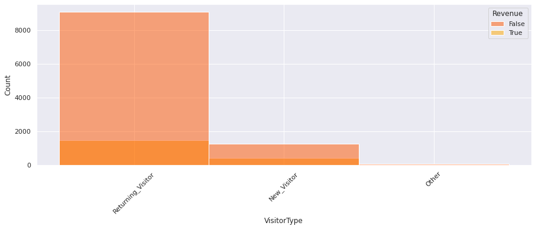

```python
plt.figure(figsize=(15,5))
sns.histplot(shop,x="VisitorType",hue="Revenue",palette="autumn",bins=5)
plt.xticks(rotation=45)
```

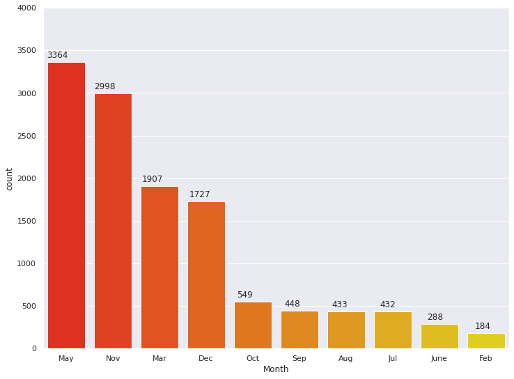

```python
sns.set(rc={'figure.figsize':(12,9)})
sns.countplot(shop["Month"],order=shop['Month'].value_counts().index,palette="autumn")
xval = -.42
plt.ylim(0,4000)

for index, value in shop['Month'].value_counts().items():
    plt.text(x=xval, y=value+50, s=str(value))
    xval += 1.02
```

**Pré-traitement des données**

```python
def LABEL_ENCODING(c1):
    from sklearn import preprocessing
    # label_encoder object knows how to understand word labels.
    label_encoder = preprocessing.LabelEncoder()

    # Encode labels in column 'species'.
    shop[c1]= label_encoder.fit_transform(shop[c1])

    shop[c1].unique()
    return shop
```

```python
LABEL_ENCODING("Revenue")
LABEL_ENCODING("Weekend")
```

|  | Administrative | Administrative_Duration | Informational | Informational_Duration | ProductRelated | ProductRelated_Duration | BounceRates | ExitRates | PageValues | SpecialDay | Month | OperatingSystems | Browser | Region | TrafficType | VisitorType | Weekend | Revenue |
| --- | --- | --- | --- | --- | --- | --- | --- | --- | --- | --- | --- | --- | --- | --- | --- | --- | --- | --- |
| 0 | 0 | 0.0 | 0 | 0.0 | 1 | 0.000000 | 0.200000 | 0.200000 | 0.000000 | 0.0 | Feb | 1 | 1 | 1 | 1 | Returning_Visitor | 0 | 0 |
| 1 | 0 | 0.0 | 0 | 0.0 | 2 | 64.000000 | 0.000000 | 0.100000 | 0.000000 | 0.0 | Feb | 2 | 2 | 1 | 2 | Returning_Visitor | 0 | 0 |
| 2 | 0 | 0.0 | 0 | 0.0 | 1 | 0.000000 | 0.200000 | 0.200000 | 0.000000 | 0.0 | Feb | 4 | 1 | 9 | 3 | Returning_Visitor | 0 | 0 |
| 3 | 0 | 0.0 | 0 | 0.0 | 2 | 2.666667 | 0.050000 | 0.140000 | 0.000000 | 0.0 | Feb | 3 | 2 | 2 | 4 | Returning_Visitor | 0 | 0 |
| 4 | 0 | 0.0 | 0 | 0.0 | 10 | 627.500000 | 0.020000 | 0.050000 | 0.000000 | 0.0 | Feb | 3 | 3 | 1 | 4 | Returning_Visitor | 1 | 0 |
| ... | ... | ... | ... | ... | ... | ... | ... | ... | ... | ... | ... | ... | ... | ... | ... | ... | ... | ... |
| 12325 | 3 | 145.0 | 0 | 0.0 | 53 | 1783.791667 | 0.007143 | 0.029031 | 12.241717 | 0.0 | Dec | 4 | 6 | 1 | 1 | Returning_Visitor | 1 | 0 |
| 12326 | 0 | 0.0 | 0 | 0.0 | 5 | 465.750000 | 0.000000 | 0.021333 | 0.000000 | 0.0 | Nov | 3 | 2 | 1 | 8 | Returning_Visitor | 1 | 0 |
| 12327 | 0 | 0.0 | 0 | 0.0 | 6 | 184.250000 | 0.083333 | 0.086667 | 0.000000 | 0.0 | Nov | 3 | 2 | 1 | 13 | Returning_Visitor | 1 | 0 |
| 12328 | 4 | 75.0 | 0 | 0.0 | 15 | 346.000000 | 0.000000 | 0.021053 | 0.000000 | 0.0 | Nov | 2 | 2 | 3 | 11 | Returning_Visitor | 0 | 0 |
| 12329 | 0 | 0.0 | 0 | 0.0 | 3 | 21.250000 | 0.000000 | 0.066667 | 0.000000 | 0.0 | Nov | 3 | 2 | 1 | 2 | New_Visitor | 1 | 0 |

11851 rows × 18 columns

```python
capture_categorical = ["Month","VisitorType","TrafficType","Region","Browser","OperatingSystems"]
#new_shop=pd.get_dummies(shop,columns=capture_categorical,dummy_na=False,drop_first=True)
new_shop=shop.copy()

label_encoder = LabelEncoder()
for col in capture_categorical:
    new_shop[col] = label_encoder.fit_transform(shop[col])

new_shop.head()
```

|  | Administrative | Administrative_Duration | Informational | Informational_Duration | ProductRelated | ProductRelated_Duration | BounceRates | ExitRates | PageValues | SpecialDay | Month | OperatingSystems | Browser | Region | TrafficType | VisitorType | Weekend | Revenue |
| --- | --- | --- | --- | --- | --- | --- | --- | --- | --- | --- | --- | --- | --- | --- | --- | --- | --- | --- |
| 0 | 0 | 0.0 | 0 | 0.0 | 1 | 0.000000 | 0.20 | 0.20 | 0.0 | 0.0 | 2 | 0 | 0 | 0 | 0 | 2 | 0 | 0 |
| 1 | 0 | 0.0 | 0 | 0.0 | 2 | 64.000000 | 0.00 | 0.10 | 0.0 | 0.0 | 2 | 1 | 5 | 0 | 10 | 2 | 0 | 0 |
| 2 | 0 | 0.0 | 0 | 0.0 | 1 | 0.000000 | 0.20 | 0.20 | 0.0 | 0.0 | 2 | 3 | 0 | 8 | 12 | 2 | 0 | 0 |
| 3 | 0 | 0.0 | 0 | 0.0 | 2 | 2.666667 | 0.05 | 0.14 | 0.0 | 0.0 | 2 | 2 | 5 | 1 | 13 | 2 | 0 | 0 |
| 4 | 0 | 0.0 | 0 | 0.0 | 10 | 627.500000 | 0.02 | 0.05 | 0.0 | 0.0 | 2 | 2 | 6 | 0 | 13 | 2 | 1 | 0 |

```python
one_encoder = OneHotEncoder(handle_unknown='ignore', sparse=False)
standard_scaler = StandardScaler()

maker = make_column_transformer(
    (standard_scaler,numerical_features),
)
```

```python
def scale_column(dataframe,list_columns,scaler):
  i=0
  for col in list_columns:
    dataframe[col]=(scaler.fit_transform(dataframe))[:,i]
    i+=1
  return dataframe
```

```python
scale_column(new_shop,numerical_features,maker)
```

|  | Administrative | Administrative_Duration | Informational | Informational_Duration | ProductRelated | ProductRelated_Duration | BounceRates | ExitRates | PageValues | SpecialDay | Month | OperatingSystems | Browser | Region | TrafficType | VisitorType | Weekend | Revenue |
| --- | --- | --- | --- | --- | --- | --- | --- | --- | --- | --- | --- | --- | --- | --- | --- | --- | --- | --- |
| 0 | -0.705471 | -0.462307 | -0.399185 | -0.247984 | -0.689097 | -0.622653 | 3.684300 | 3.254345 | -0.321338 | -0.247524 | 2 | 0 | 0 | 0 | 0 | 2 | 0 | 0 |
| 1 | -0.705471 | -0.462307 | -0.399185 | -0.247984 | -0.666716 | -0.589456 | -0.450432 | 1.188852 | -0.321338 | -0.247524 | 2 | 1 | 5 | 0 | 10 | 2 | 0 | 0 |
| 2 | -0.705471 | -0.462307 | -0.399185 | -0.247984 | -0.689097 | -0.622653 | 3.684300 | 3.254345 | -0.321338 | -0.247524 | 2 | 3 | 0 | 8 | 12 | 2 | 0 | 0 |
| 3 | -0.705471 | -0.462307 | -0.399185 | -0.247984 | -0.666716 | -0.621270 | 0.583251 | 2.015049 | -0.321338 | -0.247524 | 2 | 2 | 5 | 1 | 13 | 2 | 0 | 0 |
| 4 | -0.705471 | -0.462307 | -0.399185 | -0.247984 | -0.487665 | -0.297161 | -0.036958 | 0.156106 | -0.321338 | -0.247524 | 2 | 2 | 6 | 0 | 13 | 2 | 1 | 0 |
| ... | ... | ... | ... | ... | ... | ... | ... | ... | ... | ... | ... | ... | ... | ... | ... | ... | ... | ... |
| 12325 | 0.191743 | 0.348371 | -0.399185 | -0.247984 | 0.474734 | 0.302621 | -0.302763 | -0.277016 | 0.326873 | -0.247524 | 1 | 3 | 9 | 0 | 0 | 2 | 1 | 0 |
| 12326 | -0.705471 | -0.462307 | -0.399185 | -0.247984 | -0.599572 | -0.381063 | -0.450432 | -0.436002 | -0.321338 | -0.247524 | 7 | 2 | 5 | 0 | 17 | 2 | 1 | 0 |
| 12327 | -0.705471 | -0.462307 | -0.399185 | -0.247984 | -0.577190 | -0.527080 | 1.272373 | 0.913453 | -0.321338 | -0.247524 | 7 | 2 | 5 | 0 | 4 | 2 | 1 | 0 |
| 12328 | 0.490814 | -0.042991 | -0.399185 | -0.247984 | -0.375758 | -0.443179 | -0.450432 | -0.441800 | -0.321338 | -0.247524 | 7 | 1 | 5 | 2 | 2 | 2 | 0 | 0 |
| 12329 | -0.705471 | -0.462307 | -0.399185 | -0.247984 | -0.644334 | -0.611631 | -0.450432 | 0.500354 | -0.321338 | -0.247524 | 7 | 2 | 5 | 0 | 10 | 0 | 1 | 0 |

11851 rows × 18 columns

```python
x = new_shop.drop(columns="Revenue")
y = new_shop["Revenue"]
```

**Feature Selection**

Consists of choosing the variables with the most importance. One way to do this is to use a forest method. In the trees, the variables are prioritized according to the **gini criterion**.

According to the gini criterion, at each node of the tree, we choose the variable that maximizes the gini criterion between the remaining variables.

```
[0.05159611 0.04738012 0.02890778 0.02760925 0.06509574 0.06675481
 0.05485941 0.07524514 0.34882167 0.00789934 0.05112749 0.03035603
 0.03014994 0.04273004 0.04362645 0.01321277 0.01462792]
```

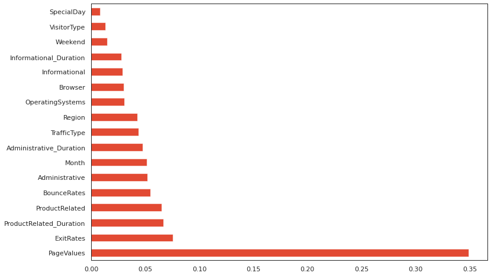

```python
model = ExtraTreesClassifier()
model.fit(x,y)

print(model.feature_importances_)

feat_importances = pd.Series(model.feature_importances_, index=x.columns)
feat_importances.nlargest(17).plot(kind='barh')
plt.show()
```

**SpecialDay,VisitorType, Weekend** seems not much importance. We can drop these columns.

```python
x = new_shop.drop(columns=["SpecialDay","VisitorType","Weekend","Revenue"],axis=1)
y = new_shop["Revenue"]

feat=list(numerical_features)

feat.append("Revenue")
feat
```

```
['Administrative',
 'Administrative_Duration',
 'Informational',
 'Informational_Duration',
 'ProductRelated',
 'ProductRelated_Duration',
 'BounceRates',
 'ExitRates',
 'PageValues',
 'SpecialDay',
 'Revenue']
```

```
[0.33551113 0.1661631  0.1027662 ]
```

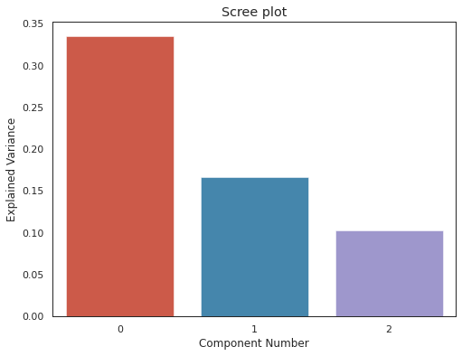

```python
n_components=3

pca = PCA(n_components=n_components)
pca.fit(new_shop[feat])
print(pca.explained_variance_ratio_)
# Do a scree plot
ind = np.arange(0, n_components)
(fig, ax) = plt.subplots(figsize=(8, 6))
sns.barplot(x=ind, y=pca.explained_variance_ratio_)
ax.set_title('Scree plot')
ax.set_xticks(ind)
ax.set_xticklabels(ind)
ax.set_xlabel('Component Number')
ax.set_ylabel('Explained Variance')
plt.show()
```

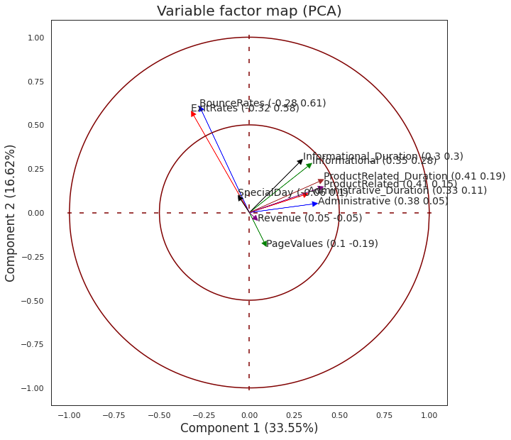

```python
pca_values=pca.components_

plt.figure(figsize=(10,10))
plt.rcParams.update({'font.size': 14})
#Plot circle#Create a list of 500 points with equal spacing between -1 and 1import numpy as np
x=np.linspace(start=-1,stop=1,num=500)#Find y1 and y2 for these points
y_positive=lambda x: np.sqrt(1-x**2)
y_negative=lambda x: -np.sqrt(1-x**2)
plt.plot(x,list(map(y_positive, x)), color='maroon')
plt.plot(x,list(map(y_negative, x)),color='maroon')
#Plot smaller circle
x=np.linspace(start=-0.5,stop=0.5,num=500)
y_positive=lambda x: np.sqrt(0.5**2-x**2)
y_negative=lambda x: -np.sqrt(0.5**2-x**2)
plt.plot(x,list(map(y_positive, x)), color='maroon')
plt.plot(x,list(map(y_negative, x)),color='maroon')
#Create broken lines
x=np.linspace(start=-1,stop=1,num=30)
plt.scatter(x,[0]*len(x), marker='_',color='maroon')
plt.scatter([0]*len(x), x, marker='|',color='maroon')
#Define color list
colors = ['blue', 'red', 'green', 'black', 'purple', 'brown']
if len(pca_values[0]) > 6:
    colors=colors*(int(len(pca_values[0])/6)+1)
add_string=""
for i in range(len(pca_values[0])):
    xi=pca_values[0][i]
    yi=pca_values[1][i]
    plt.arrow(0,0,
              dx=xi, dy=yi,
              head_width=0.03, head_length=0.03,
              color=colors[i], length_includes_head=True)
    add_string=f" ({round(xi,2)} {round(yi,2)})"
    plt.text(pca_values[0, i],
             pca_values[1, i] ,
             s=feat[i] + add_string )
plt.xlabel(f"Component 1 ({round(pca.explained_variance_ratio_[0]*100,2)}%)")
plt.ylabel(f"Component 2 ({round(pca.explained_variance_ratio_[1]*100,2)}%)")
plt.title('Variable factor map (PCA)')
plt.show()
```

PageValues which is the variable with **the most importance** is negatively correlated with the ExitRates,SpecialDay,BounceRates variables.

**SpecialDay** is very weakly correlated with Revenue.

**Split**

```python
x_train,x_test,y_train,y_test = train_test_split(x,y,test_size=0.3)

print("Shape of x_train :", x_train.shape)
print("Shape of y_train :", y_train.shape)
print("Shape of x_test :", x_test.shape)
print("Shape of y_test :", y_test.shape)
```

```
Shape of x_train : (8295, 14)
Shape of y_train : (8295,)
Shape of x_test : (3556, 14)
Shape of y_test : (3556,)
```

# MODELS

**Metrics**

There are several metrics that we could have used like **f1_score, précision_score, recall_score** purpose we preferred **accuracy, auc** metrics.

```python
classifier=[]
accuracy=[]
missclassification=[]
auc=[]
```

```python
def model(model_name,method,save=True):
  if(model_name not in ["KNN","neural network"]):
    model1 = method
    model1.fit(x_train,y_train)
  elif(model_name not in ["neural network"]):
    model1=method
    model1.fit(x_train)
  if(model_name not in ["neural network"]):
    y_pred= model1.predict(x_test)
    cm = metrics.confusion_matrix(y_test, y_pred)



  if(model_name=="neural network"):
    model1=method
    with tf.device('/device:GPU:0'):
      model1.compile(optimizer='sgd',loss='binary_crossentropy',metrics=['accuracy'])
      callback=EarlyStopping(
      monitor='val_loss', min_delta=1e-3, patience=5, verbose=1,
      mode='auto', baseline=None, restore_best_weights=True)
      model1.fit(x_train,y_train,validation_data=(x_test,y_test),callbacks=[callback],batch_size=25,verbose=2,epochs=1000)
      y_pred=model1.predict(x_test)
      classes = np.argmax(y_pred, axis = 1)
      cm=metrics.confusion_matrix(classes,y_test)


  print("-----------------------------------------","\n")
  print("Name model: ", model_name)
  print("-----------------------------------------","\n")

  TP=cm[0,0]
  TN=cm[1,1]
  FN=cm[1,0]
  FP=cm[0,1]
  sensitivity=TP/float(TP+FN)
  specificity=TN/float(TN+FP)


  if(save):
    if(model_name!="neural network" ):
      classifier.append(model_name)
      accuracy.append(accuracy_score(y_pred,y_test))
      missclassification.append(FN+FP)
      auc.append(metrics.roc_auc_score(y_test,y_pred))
    else:
      classifier.append(model_name)
      accuracy.append(accuracy_score(classes,y_test))
      missclassification.append(FN+FP)
      auc.append(metrics.roc_auc_score(y_test,classes))

  if(model_name not in ["neural network"]):
    print("Training Accuracy: ", model1.score(x_train, y_train))
    print("Testing Accuracy: ", model1.score(x_test, y_test))
    print("Accuray_score: ", accuracy_score(y_pred,y_test))
    print("True Negatives :",TN)
    print("True Positives :",TP)
    print("False Negative :",FN," (Type II error)")
    print("False Positives :",FP," (Type I error)")
    print("correctly predicted :",TP+TN)
    print("miss-classified :",FN+FP)
    print("auc :",metrics.roc_auc_score(y_test,y_pred))
  else:
    print(" Training Accuracy",model1.evaluate(x_train,y_train))
    print(" Test Accuracy",model1.evaluate(x_test,y_test))
    print("True Negatives :",TN)
    print("True Positives :",TP)
    print("False Negative :",FN," (Type II error)")
    print("False Positives :",FP," (Type I error)")
    print("correctly predicted :",TP+TN)
    print("miss-classified :",FN+FP)
    print("auc :",metrics.roc_auc_score(y_test,classes))
  plt.rcParams['figure.figsize'] = (9, 3)
  sns.heatmap(cm, annot = True)
  plt.show()
```

**Support vectort Machine**

```
-----------------------------------------

Name model:  Support vector Machine
-----------------------------------------

Training Accuracy:  0.8905109489051095
Testing Accuracy:  0.8807785888077859
Accuray_score:  0.8807785888077859
True Negatives : 215
True Positives : 3043
False Negative : 368  (Type II error)
False Positives : 73  (Type I error)
correctly predicted : 3258
miss-classified : 441
auc : 0.6726773450590876
```

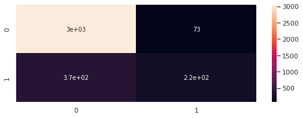

```python
model("Support vector Machine",SVC())
```

Search best parameters for SVC

```python
with tf.device('/device:GPU:0'):
  parm = {'C':[0.1,1,10,100],'gamma':[1,0.1,0.001],'kernel':['rbf','poly','sigmoid']}
  grid= GridSearchCV(SVC(),parm,refit=True,verbose=2)
  grid.fit(x_train,y_train)
```

```
Fitting 5 folds for each of 36 candidates, totalling 180 fits
[CV] END .........................C=0.1, gamma=1, kernel=rbf; total time=   6.6s
[CV] END .........................C=0.1, gamma=1, kernel=rbf; total time=   6.4s
[CV] END .........................C=0.1, gamma=1, kernel=rbf; total time=   6.1s
[CV] END .........................C=0.1, gamma=1, kernel=rbf; total time=   6.1s
[CV] END .........................C=0.1, gamma=1, kernel=rbf; total time=   6.4s
[CV] END ........................C=0.1, gamma=1, kernel=poly; total time=  12.7s
[CV] END ........................C=0.1, gamma=1, kernel=poly; total time=  14.6s
[CV] END ........................C=0.1, gamma=1, kernel=poly; total time=  14.0s
[CV] END ........................C=0.1, gamma=1, kernel=poly; total time=  14.8s
[CV] END ........................C=0.1, gamma=1, kernel=poly; total time=  17.7s
[CV] END .....................C=0.1, gamma=1, kernel=sigmoid; total time=   2.9s
[CV] END .....................C=0.1, gamma=1, kernel=sigmoid; total time=   2.7s
[CV] END .....................C=0.1, gamma=1, kernel=sigmoid; total time=   2.8s
[CV] END .....................C=0.1, gamma=1, kernel=sigmoid; total time=   2.8s
[CV] END .....................C=0.1, gamma=1, kernel=sigmoid; total time=   2.6s
[CV] END .......................C=0.1, gamma=0.1, kernel=rbf; total time=   2.4s
[CV] END .......................C=0.1, gamma=0.1, kernel=rbf; total time=   2.5s
[CV] END .......................C=0.1, gamma=0.1, kernel=rbf; total time=   2.3s
[CV] END .......................C=0.1, gamma=0.1, kernel=rbf; total time=   2.4s
[CV] END .......................C=0.1, gamma=0.1, kernel=rbf; total time=   2.4s
[CV] END ......................C=0.1, gamma=0.1, kernel=poly; total time=   2.3s
[CV] END ......................C=0.1, gamma=0.1, kernel=poly; total time=   2.4s
[CV] END ......................C=0.1, gamma=0.1, kernel=poly; total time=   2.2s
[CV] END ......................C=0.1, gamma=0.1, kernel=poly; total time=   2.3s
[CV] END ......................C=0.1, gamma=0.1, kernel=poly; total time=   2.1s
[CV] END ...................C=0.1, gamma=0.1, kernel=sigmoid; total time=   2.0s
[CV] END ...................C=0.1, gamma=0.1, kernel=sigmoid; total time=   1.8s
[CV] END ...................C=0.1, gamma=0.1, kernel=sigmoid; total time=   1.7s
[CV] END ...................C=0.1, gamma=0.1, kernel=sigmoid; total time=   1.5s
[CV] END ...................C=0.1, gamma=0.1, kernel=sigmoid; total time=   1.5s
[CV] END .....................C=0.1, gamma=0.001, kernel=rbf; total time=   2.1s
[CV] END .....................C=0.1, gamma=0.001, kernel=rbf; total time=   2.2s
[CV] END .....................C=0.1, gamma=0.001, kernel=rbf; total time=   2.2s
[CV] END .....................C=0.1, gamma=0.001, kernel=rbf; total time=   2.2s
[CV] END .....................C=0.1, gamma=0.001, kernel=rbf; total time=   2.1s
[CV] END ....................C=0.1, gamma=0.001, kernel=poly; total time=   1.5s
[CV] END ....................C=0.1, gamma=0.001, kernel=poly; total time=   1.5s
[CV] END ....................C=0.1, gamma=0.001, kernel=poly; total time=   1.6s
[CV] END ....................C=0.1, gamma=0.001, kernel=poly; total time=   1.5s
```

[output cut: 126 more lines]

```
[CV] END .....................C=100, gamma=0.001, kernel=rbf; total time=   2.5s
[CV] END .....................C=100, gamma=0.001, kernel=rbf; total time=   2.5s
[CV] END .....................C=100, gamma=0.001, kernel=rbf; total time=   2.4s
[CV] END .....................C=100, gamma=0.001, kernel=rbf; total time=   2.5s
[CV] END .....................C=100, gamma=0.001, kernel=rbf; total time=   2.4s
[CV] END ....................C=100, gamma=0.001, kernel=poly; total time=   1.7s
[CV] END ....................C=100, gamma=0.001, kernel=poly; total time=   1.7s
[CV] END ....................C=100, gamma=0.001, kernel=poly; total time=   1.9s
[CV] END ....................C=100, gamma=0.001, kernel=poly; total time=   1.8s
[CV] END ....................C=100, gamma=0.001, kernel=poly; total time=   1.9s
[CV] END .................C=100, gamma=0.001, kernel=sigmoid; total time=   2.1s
[CV] END .................C=100, gamma=0.001, kernel=sigmoid; total time=   2.1s
[CV] END .................C=100, gamma=0.001, kernel=sigmoid; total time=   2.0s
[CV] END .................C=100, gamma=0.001, kernel=sigmoid; total time=   2.0s
[CV] END .................C=100, gamma=0.001, kernel=sigmoid; total time=   2.0s
```

```python
grid.best_estimator_
```

```
SVC(C=1, gamma=0.1)
```

```
-----------------------------------------

Name model:  Support vector machine Tunned
-----------------------------------------

Training Accuracy:  0.9177383848916696
Testing Accuracy:  0.8813192754798594
Accuray_score:  0.8813192754798594
True Negatives : 210
True Positives : 3050
False Negative : 373  (Type II error)
False Positives : 66  (Type I error)
correctly predicted : 3260
miss-classified : 439
auc : 0.6695124153101241
```

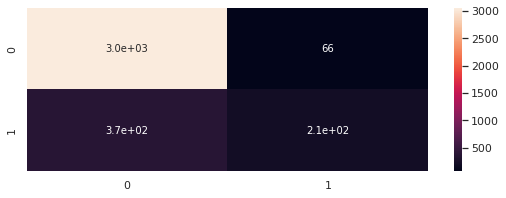

```python
model("Support vector machine Tunned", SVC(C=1,gamma=0.1))
```

**Logistic Regression**

```
-----------------------------------------

Name model:  Regression Logistic
-----------------------------------------

Training Accuracy:  0.8876144131618584
Testing Accuracy:  0.878345498783455
Accuray_score:  0.878345498783455
True Negatives : 200
True Positives : 3049
False Negative : 383  (Type II error)
False Positives : 67  (Type I error)
correctly predicted : 3249
miss-classified : 450
auc : 0.6607756238481406
```

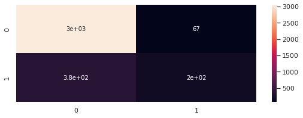

```python
model("Regression Logistic",LogisticRegression())
```

Search best parameters for logistic regression

```python
with tf.device('/device:GPU:0'):
  logistic=LogisticRegression()
  parm = {'C':[0.1,1,10,100]}
  grid= RandomizedSearchCV(estimator=logistic,param_distributions = parm, cv = 2, verbose=2, random_state=42, n_jobs = -1)
  grid.fit(x_train,y_train)
```

[output not shown]

```
-----------------------------------------

Name model:  Logistic Regression tunned
-----------------------------------------

Training Accuracy:  0.8866875217240181
Testing Accuracy:  0.8780751554474182
Accuray_score:  0.8780751554474182
True Negatives : 197
True Positives : 3051
False Negative : 386  (Type II error)
False Positives : 65  (Type I error)
correctly predicted : 3248
miss-classified : 451
auc : 0.658523649310701
```

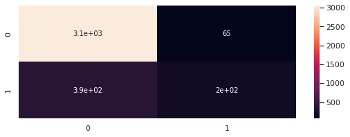

```python
best_logistic= grid.best_estimator_
model("Logistic Regression tunned", best_logistic)
```

**Linear Discriminant Analysis**

```
-----------------------------------------

Name model:  LDA
-----------------------------------------

Training Accuracy:  0.8827482331131966
Testing Accuracy:  0.8737496620708299
Accuray_score:  0.8737496620708299
True Negatives : 178
True Positives : 3054
False Negative : 405  (Type II error)
False Positives : 62  (Type I error)
correctly predicted : 3232
miss-classified : 467
auc : 0.6427100099745242
```

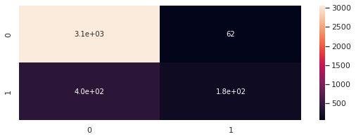

```python
model("LDA", LinearDiscriminantAnalysis())
```

**Quadratic Discriminant Analysis**

```
-----------------------------------------

Name model:  QDA
-----------------------------------------

Training Accuracy:  0.848569111342834
Testing Accuracy:  0.8542849418761828
Accuray_score:  0.8542849418761828
True Negatives : 336
True Positives : 2824
False Negative : 247  (Type II error)
False Positives : 292  (Type I error)
correctly predicted : 3160
miss-classified : 539
auc : 0.7413097232895233
```

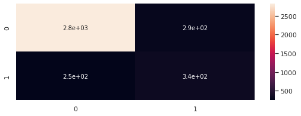

```python
model("QDA", QuadraticDiscriminantAnalysis())
```

**KNN**

```
-----------------------------------------

Name model:  KNN
-----------------------------------------

Training Accuracy:  0.9005908932916232
Testing Accuracy:  0.8656393619897269
Accuray_score:  0.8656393619897269
True Negatives : 185
True Positives : 3017
False Negative : 398  (Type II error)
False Positives : 99  (Type I error)
correctly predicted : 3202
miss-classified : 497
auc : 0.6427763416615839
```

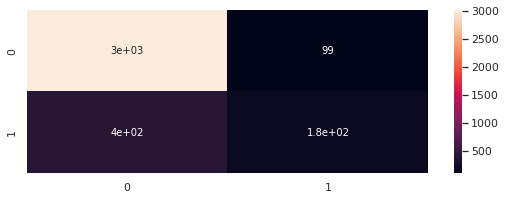

```python
model("KNN", KNeighborsClassifier())
```

```python
# Number of neighbors
n_neighbors = [int(x) for x in np.linspace(start = 1, stop = 20, num = 5)]
# Maximum number of levels in tree
# Create the random grid
random_grid = {'n_neighbors': n_neighbors}
```

```python
with tf.device('/device:GPU:0'):
    knn = KNeighborsClassifier(weights='distance', metric='euclidean')
    # Random search of parameters, using 2 fold cross validation,
    # search across all different combinations, and use all available cores
    knn_random = RandomizedSearchCV(estimator = knn, param_distributions = random_grid, cv = 2, verbose=2, random_state=42, n_jobs = -1)
    # Fit the random search model
    knn_random.fit(x_train, y_train)
```

```
Fitting 2 folds for each of 5 candidates, totalling 10 fits
```

```
-----------------------------------------

Name model:  KNN Tuned
-----------------------------------------

Training Accuracy:  1.0
Testing Accuracy:  0.8675317653419843
Accuray_score:  0.8675317653419843
True Negatives : 159
True Positives : 3050
False Negative : 424  (Type II error)
False Positives : 66  (Type I error)
correctly predicted : 3209
miss-classified : 490
auc : 0.6257731357217878
```

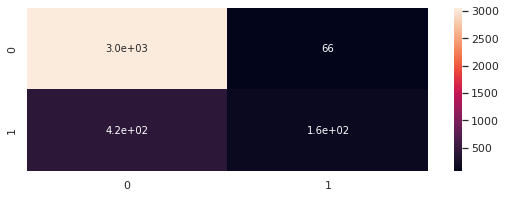

```python
knn_random.best_params_
best_knn = knn_random.best_estimator_
model("KNN Tuned", best_knn)
```

**RandomForestClassifier**

```
-----------------------------------------

Name model:  Random Forest classifier
-----------------------------------------

Training Accuracy:  1.0
Testing Accuracy:  0.8986212489862125
Accuray_score:  0.8986212489862125
True Negatives : 306
True Positives : 3018
False Negative : 277  (Type II error)
False Positives : 98  (Type I error)
correctly predicted : 3324
miss-classified : 375
auc : 0.7467103886981815
```

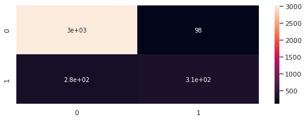

```python
model("Random Forest classifier" ,RandomForestClassifier())
```

```python
# Number of trees in random forest
n_estimators = [int(x) for x in np.linspace(start = 1, stop = 50, num = 3)]
# Maximum number of levels in tree
max_depth = [int(x) for x in np.linspace(10, 20, num = 2)]
max_depth.append(None)
# Create the random grid
random_grid = {'n_estimators': n_estimators,
               'max_depth': max_depth}

rf = RandomForestClassifier()
    # Random search of parameters, using 3 fold cross validation,
    # search across all different combinations, and use all available cores
rf_random = RandomizedSearchCV(estimator = rf, param_distributions = random_grid, cv = 2, verbose=2, random_state=42, n_jobs = -1)
    # Fit the random search model
rf_random.fit(x_train, y_train)
```

```
Fitting 2 folds for each of 9 candidates, totalling 18 fits
```

```
RandomizedSearchCV(cv=2, estimator=RandomForestClassifier(), n_jobs=-1,
                   param_distributions={'max_depth': [10, 20, None],
                                        'n_estimators': [1, 25, 50]},
                   random_state=42, verbose=2)
```

```python
rf_random.best_params_
```

```
{'max_depth': 10, 'n_estimators': 50}
```

```
-----------------------------------------

Name model:  Random Forest Tunned
-----------------------------------------

Training Accuracy:  0.9502954466458116
Testing Accuracy:  0.9010543390105434
Accuray_score:  0.9010543390105434
True Negatives : 316
True Positives : 3017
False Negative : 267  (Type II error)
False Positives : 99  (Type I error)
correctly predicted : 3333
miss-classified : 366
auc : 0.7551262558982907
```

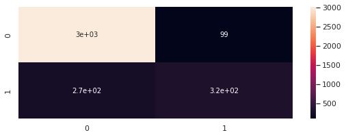

```python
best_rf = rf_random.best_estimator_
model("Random Forest Tunned",best_rf)
```

**BaggingClassifier**

```
-----------------------------------------

Name model:  Bagging classifier
-----------------------------------------

Training Accuracy:  0.9903835013324065
Testing Accuracy:  0.8983509056501757
Accuray_score:  0.8983509056501757
True Negatives : 309
True Positives : 3014
False Negative : 274  (Type II error)
False Positives : 102  (Type I error)
correctly predicted : 3323
miss-classified : 376
auc : 0.7486414389737469
```

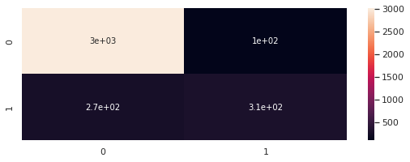

```python
model("Bagging classifier",BaggingClassifier())
```

```python
n_estimators = [int(x) for x in np.linspace(start = 1, stop = 50, num = 6)]
# Maximum number of levels in tree
# Create the random grid
random_grid = {'n_estimators': n_estimators}

with tf.device('/device:GPU:0'):
    bagging = BaggingClassifier(base_estimator=DecisionTreeClassifier())
    # Random search of parameters, using 2 fold cross validation,
    # search across all combinations, and use all available cores
    bagging_random = RandomizedSearchCV(estimator = bagging, param_distributions = random_grid, cv = 2, verbose=2, random_state=42, n_jobs = -1)
    # Fit the random search model
    bagging_random.fit(x_train, y_train)
```

```
Fitting 2 folds for each of 6 candidates, totalling 12 fits
```

```
-----------------------------------------

Name model:  bagging classifier tunned
-----------------------------------------

Training Accuracy:  0.99976827714054
Testing Accuracy:  0.9018653690186537
Accuray_score:  0.9018653690186537
True Negatives : 334
True Positives : 3002
False Negative : 249  (Type II error)
False Positives : 114  (Type I error)
correctly predicted : 3336
miss-classified : 363
auc : 0.7681567167301175
```

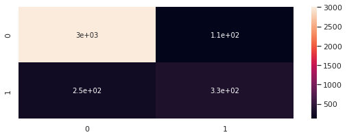

```python
bagging=bagging_random.best_estimator_
model("bagging classifier tunned",bagging)
```

**AdaBoostClassifier**

```
-----------------------------------------

Name model:  ada boost classifier
-----------------------------------------

Training Accuracy:  0.8939867917970108
Testing Accuracy:  0.8872668288726683
Accuray_score:  0.8872668288726683
True Negatives : 311
True Positives : 2971
False Negative : 272  (Type II error)
False Positives : 145  (Type I error)
correctly predicted : 3282
miss-classified : 417
auc : 0.7434568332096609
```

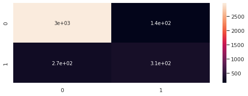

```python
model("ada boost classifier",AdaBoostClassifier())
```

```python
with tf.device('/device:GPU:0'):

  ada_tunned=AdaBoostClassifier(random_state=0)
  params = {
      'n_estimators': [int(x) for x in np.linspace(start = 1, stop = 50, num = 6)],
  }

  ada_boost=RandomizedSearchCV(ada_tunned,param_distributions=params,cv=3,n_iter=200,n_jobs=-1,random_state=0)

  ada_boost.fit(x_train,y_train)
```

```
-----------------------------------------

Name model:  adaboost classifier Tunned
-----------------------------------------

Training Accuracy:  0.8954929903835014
Testing Accuracy:  0.88294133549608
Accuray_score:  0.88294133549608
True Negatives : 303
True Positives : 2963
False Negative : 280  (Type II error)
False Positives : 153  (Type I error)
correctly predicted : 3266
miss-classified : 433
auc : 0.7353120726973272
```

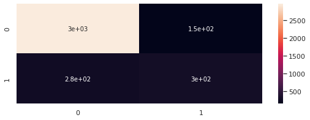

```python
best_ada = ada_boost.best_estimator_
model("adaboost classifier Tunned",best_ada)
```

**XGBClassifier**

```python
with tf.device('/device:GPU:0'):

  XGB_tunned=XGBClassifier(random_state=0)
  params = {
        'min_child_weight': sp_randint(1,20),
        'gamma': [0.5, 1, 1.5, 2, 5],
        'subsample': [0.6, 0.8, 1.0],
        'colsample_bytree': [0.6, 0.8, 1.0],
        'max_depth': sp_randint(2,10)
        }

  rsearch_xgb=RandomizedSearchCV(XGB_tunned,param_distributions=params,cv=3,n_iter=200,n_jobs=-1,random_state=0)

  rsearch_xgb.fit(x_train,y_train)
```

```
-----------------------------------------

Name model:  Xgb tunned
-----------------------------------------

Training Accuracy:  0.9206349206349206
Testing Accuracy:  0.903757772370911
Accuray_score:  0.903757772370911
True Negatives : 339
True Positives : 3004
False Negative : 244  (Type II error)
False Positives : 112  (Type I error)
correctly predicted : 3343
miss-classified : 356
auc : 0.7727658056575148
```

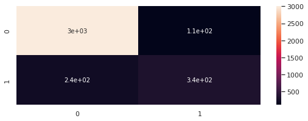

```python
best_xgb=rsearch_xgb.best_estimator_
model("Xgb tunned",best_xgb)
```

**GradientBoostingClassifier**

```
-----------------------------------------

Name model:  Gradient boosting
-----------------------------------------

Training Accuracy:  0.9212142277835709
Testing Accuracy:  0.902676399026764
Accuray_score:  0.902676399026764
True Negatives : 343
True Positives : 2996
False Negative : 240  (Type II error)
False Positives : 120  (Type I error)
correctly predicted : 3339
miss-classified : 360
auc : 0.7749126403424366
```

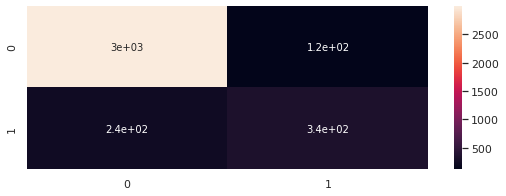

```python
model("Gradient boosting",GradientBoostingClassifier())
```

```python
with tf.device('/device:GPU:0'):
  gradient_boost_tunned=GradientBoostingClassifier(random_state=0)
  params = {
        'n_estimators': [int(x) for x in np.linspace(start = 1, stop = 50, num = 6)],
        }

  rsearch_boost=RandomizedSearchCV(gradient_boost_tunned,param_distributions=params,cv=3,n_iter=200,n_jobs=-1,random_state=0)

  rsearch_boost.fit(x_train,y_train)
```

```
-----------------------------------------

Name model:  gradient boosting tunned
-----------------------------------------

Training Accuracy:  0.916463909164639
Testing Accuracy:  0.9032170856988375
Accuray_score:  0.9032170856988375
True Negatives : 337
True Positives : 3004
False Negative : 246  (Type II error)
False Positives : 112  (Type I error)
correctly predicted : 3341
miss-classified : 358
auc : 0.7710505397913057
```

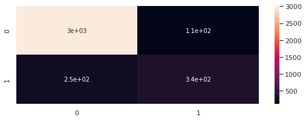

```python
best_gradient_boost = rsearch_boost.best_estimator_
model("gradient boosting tunned",best_gradient_boost)
```

**DecisionTreeClassifier**

```
-----------------------------------------

Name model:  Decision Tree Classifier
-----------------------------------------

Training Accuracy:  1.0
Testing Accuracy:  0.8640173019735063
Accuray_score:  0.8640173019735063
True Negatives : 338
True Positives : 2858
False Negative : 245  (Type II error)
False Positives : 258  (Type I error)
correctly predicted : 3196
miss-classified : 503
auc : 0.7484807016075938
```

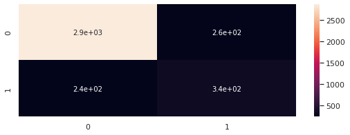

```python
model("Decision Tree Classifier",DecisionTreeClassifier())
```

**Reseau de neurones**

```python
model2= Sequential()
model2.add(Dense(units=64,input_dim=14, activation='relu',kernel_initializer='uniform'))
model2.add(Dense(units=16, activation='relu'))
model2.add(Dropout(.2))
model2.add(Dense(units=4 , activation='relu'))
model2.add(Dropout(.42))
model2.add(Dense(units=1,activation='sigmoid'))

model2.summary()
```

```
Model: "sequential_2"
_________________________________________________________________
 Layer (type)                Output Shape              Param #
=================================================================
 dense_9 (Dense)             (None, 64)                960

 dense_10 (Dense)            (None, 16)                1040

 dropout_4 (Dropout)         (None, 16)                0

 dense_11 (Dense)            (None, 4)                 68

 dropout_5 (Dropout)         (None, 4)                 0

 dense_12 (Dense)            (None, 1)                 5

=================================================================
Total params: 2,073
Trainable params: 2,073
Non-trainable params: 0
_________________________________________________________________
```